# Logistic Regression for Money Loan approve

Tutorial R markdown: This is an [R Markdown](http://rmarkdown.rstudio.com)

Execute chunk: Click the *Run* button within the chunk or by place your cursor inside and press *Ctrl+Shift+Enter*.

Add new chunk: Click *Insert Chunk* button on the toolbar or by press *Ctrl+Alt+I*.

Display HTML preview: Click the *Preview* button or press *Ctrl+Shift+K*.

## Show actual directory

```r
getwd()
```

```
[1] "C:/R_archives"
```

## Packages installation

import name in py

```r
# Install
install.packages('ROCR')   # p/ ROC curve
install.packages('caret', dependencies = True)  # p/ machine learning models
```

```
Error in install.packages : Updating loaded packages
```

```r
install.packages('e1071', dependencies = True)
```

```
Error in install.packages : Updating loaded packages
```

```r
# Load
library(caret)
library(ROCR)
library(e1071)
```

## Load

df = pd.read(csv) in py  
note: this dataset has no missing values (NA’s) nor outliers!

```r
dataset_cred <- read.csv('credit_dataset.csv', header = TRUE, sep = ',')
```

## Data first 5 rows

df.head(5) in py

```r
head( dataset_cred, 5  )
```

|  | credit.rating | account.balance | credit.duration.months | previous.credit.payment.status | credit.purpose | credit.amount | savings | employment.duration | installment.rate | marital.status | guarantor | residence.duration | current.assets | age | other.credits | apartment.type | bank.credits | occupation | dependents | telephone | foreign.worker |
| --- | --- | --- | --- | --- | --- | --- | --- | --- | --- | --- | --- | --- | --- | --- | --- | --- | --- | --- | --- | --- | --- |
| 1 | 1 | 1 | 18 | 3 | 2 | 1049 | 1 | 1 | 4 | 1 | 1 | 4 | 2 | 21 | 2 | 1 | 1 | 3 | 1 | 1 | 1 |
| 2 | 1 | 1 | 9 | 3 | 4 | 2799 | 1 | 2 | 2 | 3 | 1 | 2 | 1 | 36 | 2 | 1 | 2 | 3 | 2 | 1 | 1 |
| 3 | 1 | 2 | 12 | 2 | 4 | 841 | 2 | 3 | 2 | 1 | 1 | 4 | 1 | 23 | 2 | 1 | 1 | 2 | 1 | 1 | 1 |
| 4 | 1 | 1 | 12 | 3 | 4 | 2122 | 1 | 2 | 3 | 3 | 1 | 2 | 1 | 39 | 2 | 1 | 2 | 2 | 2 | 1 | 2 |
| 5 | 1 | 1 | 12 | 3 | 4 | 2171 | 1 | 2 | 4 | 3 | 1 | 4 | 2 | 38 | 1 | 2 | 2 | 2 | 1 | 1 | 2 |

## Data general statistics

df.describe() in py

```r
summary( dataset_cred )
```

```
 credit.rating account.balance credit.duration.months previous.credit.payment.status
 Min.   :0.0   Min.   :1.000   Min.   : 4.0           Min.   :1.000
 1st Qu.:0.0   1st Qu.:1.000   1st Qu.:12.0           1st Qu.:2.000
 Median :1.0   Median :2.000   Median :18.0           Median :2.000
 Mean   :0.7   Mean   :2.183   Mean   :20.9           Mean   :2.292
 3rd Qu.:1.0   3rd Qu.:3.000   3rd Qu.:24.0           3rd Qu.:3.000
 Max.   :1.0   Max.   :3.000   Max.   :72.0           Max.   :3.000
 credit.purpose  credit.amount      savings      employment.duration installment.rate
 Min.   :1.000   Min.   :  250   Min.   :1.000   Min.   :1.000       Min.   :1.000
 1st Qu.:2.000   1st Qu.: 1366   1st Qu.:1.000   1st Qu.:2.000       1st Qu.:2.000
 Median :3.000   Median : 2320   Median :1.000   Median :2.000       Median :3.000
 Mean   :2.965   Mean   : 3271   Mean   :1.874   Mean   :2.446       Mean   :2.973
 3rd Qu.:4.000   3rd Qu.: 3972   3rd Qu.:3.000   3rd Qu.:4.000       3rd Qu.:4.000
 Max.   :4.000   Max.   :18424   Max.   :4.000   Max.   :4.000       Max.   :4.000
 marital.status    guarantor     residence.duration current.assets       age
 Min.   :1.000   Min.   :1.000   Min.   :1.000      Min.   :1.000   Min.   :19.00
 1st Qu.:1.000   1st Qu.:1.000   1st Qu.:2.000      1st Qu.:1.000   1st Qu.:27.00
 Median :3.000   Median :1.000   Median :3.000      Median :2.000   Median :33.00
 Mean   :2.372   Mean   :1.093   Mean   :2.845      Mean   :2.358   Mean   :35.54
 3rd Qu.:3.000   3rd Qu.:1.000   3rd Qu.:4.000      3rd Qu.:3.000   3rd Qu.:42.00
 Max.   :4.000   Max.   :2.000   Max.   :4.000      Max.   :4.000   Max.   :75.00
 other.credits   apartment.type   bank.credits     occupation      dependents
 Min.   :1.000   Min.   :1.000   Min.   :1.000   Min.   :1.000   Min.   :1.000
 1st Qu.:2.000   1st Qu.:2.000   1st Qu.:1.000   1st Qu.:3.000   1st Qu.:1.000
 Median :2.000   Median :2.000   Median :1.000   Median :3.000   Median :1.000
 Mean   :1.814   Mean   :1.928   Mean   :1.367   Mean   :2.904   Mean   :1.155
 3rd Qu.:2.000   3rd Qu.:2.000   3rd Qu.:2.000   3rd Qu.:3.000   3rd Qu.:1.000
 Max.   :2.000   Max.   :3.000   Max.   :2.000   Max.   :4.000   Max.   :2.000
   telephone     foreign.worker
 Min.   :1.000   Min.   :1.000
 1st Qu.:1.000   1st Qu.:1.000
 Median :1.000   Median :1.000
 Mean   :1.404   Mean   :1.037
 3rd Qu.:2.000   3rd Qu.:1.000
 Max.   :2.000   Max.   :2.000
```

## Data types of the Structure

df.dtypes in py

```r
str( dataset_cred )
```

```
'data.frame':   1000 obs. of  21 variables:
 $ credit.rating                 : int  1 1 1 1 1 1 1 1 1 1 ...
 $ account.balance               : int  1 1 2 1 1 1 1 1 3 2 ...
 $ credit.duration.months        : int  18 9 12 12 12 10 8 6 18 24 ...
 $ previous.credit.payment.status: int  3 3 2 3 3 3 3 3 3 2 ...
 $ credit.purpose                : int  2 4 4 4 4 4 4 4 3 3 ...
 $ credit.amount                 : int  1049 2799 841 2122 2171 2241 3398 1361 1098 3758 ...
 $ savings                       : int  1 1 2 1 1 1 1 1 1 3 ...
 $ employment.duration           : int  1 2 3 2 2 1 3 1 1 1 ...
 $ installment.rate              : int  4 2 2 3 4 1 1 2 4 1 ...
 $ marital.status                : int  1 3 1 3 3 3 3 3 1 1 ...
 $ guarantor                     : int  1 1 1 1 1 1 1 1 1 1 ...
 $ residence.duration            : int  4 2 4 2 4 3 4 4 4 4 ...
 $ current.assets                : int  2 1 1 1 2 1 1 1 3 4 ...
 $ age                           : int  21 36 23 39 38 48 39 40 65 23 ...
 $ other.credits                 : int  2 2 2 2 1 2 2 2 2 2 ...
 $ apartment.type                : int  1 1 1 1 2 1 2 2 2 1 ...
 $ bank.credits                  : int  1 2 1 2 2 2 2 1 2 1 ...
 $ occupation                    : int  3 3 2 2 2 2 2 2 1 1 ...
 $ dependents                    : int  1 2 1 2 1 2 1 2 1 1 ...
 $ telephone                     : int  1 1 1 1 1 1 1 1 1 1 ...
 $ foreign.worker                : int  1 1 1 2 2 2 2 2 1 1 ...
```

## Opening a new tab to view the dataset

```r
View( dataset_cred )
```

What is factor variables in R?“  
https://www.guru99.com/r-factor-categorical-continuous.html

```r
to.factors <- function( dataset, variables ){
  for (var in variables){
    dataset[[ var ]] <- as.factor( dataset[[ var ]] )
  }
  return (dataset)
}
```

## Create normalization function

```r
scale.features <- function( dataset, variables ){
  for (var in variables){
    dataset[[ var ]] <- scale( dataset[[ var ]], center = T, scale = T )
  }
  return (dataset)
}
```

## Aplly normalization function above for 3 numeric variables

```r
ds_numeric.vars <- c( 'age', 'credit.duration.months', 'credit.amount'  )

dataset_cred_scaled <- scale.features( dataset_cred, ds_numeric.vars )
```

## Apply ‘to.factors’ function created above for misclassified categorical variables

```r
ds_categorical.vars <- c( 'credit.rating', 'account.balance', 'previous.credit.payment.status',
                          'credit.purpose', 'savings', 'employment.duration',
                          'installment.rate', 'marital.status', 'guarantor',
                          'residence.duration', 'current.assets',  'other.credits',                                           'apartment.type', 'bank.credits', 'occupation',
                          'dependents', 'telephone', 'foreign.worker' )

dataset_cred <- to.factors( dataset = dataset_cred_scaled, variables = ds_categorical.vars )
```

## Checking new ds data types

```r
str( dataset_cred )
```

```
'data.frame':   1000 obs. of  21 variables:
 $ credit.rating                 : Factor w/ 2 levels "0","1": 2 2 2 2 2 2 2 2 2 2 ...
 $ account.balance               : Factor w/ 3 levels "1","2","3": 1 1 2 1 1 1 1 1 3 2 ...
 $ credit.duration.months        : num [1:1000, 1] -0.241 -0.987 -0.738 -0.738 -0.738 ...
  ..- attr(*, "scaled:center")= num 20.9
  ..- attr(*, "scaled:scale")= num 12.1
 $ previous.credit.payment.status: Factor w/ 3 levels "1","2","3": 3 3 2 3 3 3 3 3 3 2 ...
 $ credit.purpose                : Factor w/ 4 levels "1","2","3","4": 2 4 4 4 4 4 4 4 3 3 ...
 $ credit.amount                 : num [1:1000, 1] -0.787 -0.167 -0.861 -0.407 -0.39 ...
  ..- attr(*, "scaled:center")= num 3271
  ..- attr(*, "scaled:scale")= num 2823
 $ savings                       : Factor w/ 4 levels "1","2","3","4": 1 1 2 1 1 1 1 1 1 3 ...
 $ employment.duration           : Factor w/ 4 levels "1","2","3","4": 1 2 3 2 2 1 3 1 1 1 ...
 $ installment.rate              : Factor w/ 4 levels "1","2","3","4": 4 2 2 3 4 1 1 2 4 1 ...
 $ marital.status                : Factor w/ 3 levels "1","3","4": 1 2 1 2 2 2 2 2 1 1 ...
 $ guarantor                     : Factor w/ 2 levels "1","2": 1 1 1 1 1 1 1 1 1 1 ...
 $ residence.duration            : Factor w/ 4 levels "1","2","3","4": 4 2 4 2 4 3 4 4 4 4 ...
 $ current.assets                : Factor w/ 4 levels "1","2","3","4": 2 1 1 1 2 1 1 1 3 4 ...
 $ age                           : num [1:1000, 1] -1.2809 0.0403 -1.1048 0.3046 0.2165 ...
  ..- attr(*, "scaled:center")= num 35.5
  ..- attr(*, "scaled:scale")= num 11.4
 $ other.credits                 : Factor w/ 2 levels "1","2": 2 2 2 2 1 2 2 2 2 2 ...
 $ apartment.type                : Factor w/ 3 levels "1","2","3": 1 1 1 1 2 1 2 2 2 1 ...
 $ bank.credits                  : Factor w/ 2 levels "1","2": 1 2 1 2 2 2 2 1 2 1 ...
 $ occupation                    : Factor w/ 4 levels "1","2","3","4": 3 3 2 2 2 2 2 2 1 1 ...
 $ dependents                    : Factor w/ 2 levels "1","2": 1 2 1 2 1 2 1 2 1 1 ...
 $ telephone                     : Factor w/ 2 levels "1","2": 1 1 1 1 1 1 1 1 1 1 ...
 $ foreign.worker                : Factor w/ 2 levels "1","2": 1 1 1 2 2 2 2 2 1 1 ...
```

## Splitting data into Train and Test

```r
# Random sample of size 70%
indexes_70_percent_sample <- sample( 1:nrow( dataset_cred ), size = 0.7 * nrow( dataset_cred ) )

train.data <- dataset_cred[indexes_70_percent_sample, ]
test.data  <- dataset_cred[-indexes_70_percent_sample, ]
```

## Checking train and test types

```r
class(train.data)
```

```
[1] "data.frame"
```

```r
class(test.data)
```

```
[1] "data.frame"
```

## Splitting explanatory variables and target variable

```r
test.feature.variables <- test.data[ , -1]
test.class.variable <- test.data[ , 1]     # "credit.rating"
```

## Checking explanatory and target types

```r
class(test.feature.variables)
```

```
[1] "data.frame"
```

```r
class(test.class.variable)
```

```
[1] "factor"
```

## Logistic Model construction

- We use a formula where what comes before tilde (~) is the target variables, and what comes next are explanatory variables  
  Obs: “.” (dot) is an abbreviation for “all variables”
- We use the function `glm()` for the model construction
- We use family as binomial because it’s a binary classification (logistic: [0,1])

```r
formula.string.init <- 'credit.rating ~ .'
formula <- as.formula(formula.string.init)

model_rl_1 <- glm( formula = formula, data = train.data, family = 'binomial' )
```

## Checking the summary of the model above

```r
summary( model_rl_1 )
```

```
Call:
glm(formula = formula, family = "binomial", data = train.data)

Deviance Residuals:
    Min       1Q   Median       3Q      Max
-2.6779  -0.7463   0.4151   0.7071   1.8652

Coefficients:
                                Estimate Std. Error z value Pr(>|z|)
(Intercept)                      0.83036    0.97173   0.855 0.392818
account.balance2                 0.48923    0.25329   1.931 0.053425 .
account.balance3                 1.51001    0.25881   5.835 5.39e-09 ***
credit.duration.months          -0.24545    0.13080  -1.877 0.060581 .
previous.credit.payment.status2  0.64969    0.34686   1.873 0.061058 .
previous.credit.payment.status3  1.09746    0.36484   3.008 0.002629 **
credit.purpose2                 -1.07887    0.47049  -2.293 0.021845 *
credit.purpose3                 -1.09170    0.44709  -2.442 0.014616 *
credit.purpose4                 -1.65433    0.43334  -3.818 0.000135 ***
credit.amount                   -0.41463    0.15370  -2.698 0.006981 **
savings2                         0.16963    0.33732   0.503 0.615059
savings3                         0.84681    0.38995   2.172 0.029886 *
savings4                         1.04531    0.30526   3.424 0.000616 ***
employment.duration2             0.60154    0.28752   2.092 0.036421 *
employment.duration3             1.09783    0.33184   3.308 0.000939 ***
employment.duration4             0.48288    0.31613   1.527 0.126640
installment.rate2               -0.30775    0.38079  -0.808 0.418978
installment.rate3               -0.69740    0.41170  -1.694 0.090273 .
installment.rate4               -1.12312    0.37089  -3.028 0.002461 **
marital.status3                  0.61588    0.23375   2.635 0.008419 **
marital.status4                  0.10403    0.37285   0.279 0.780227
guarantor2                       0.11290    0.34139   0.331 0.740871
residence.duration2             -0.73255    0.35596  -2.058 0.039596 *
residence.duration3             -0.70925    0.39521  -1.795 0.072710 .
residence.duration4             -0.53502    0.34784  -1.538 0.124024
current.assets2                 -0.19799    0.28997  -0.683 0.494739
current.assets3                 -0.13334    0.27894  -0.478 0.632646
current.assets4                 -0.73855    0.49209  -1.501 0.133394
age                              0.03184    0.11785   0.270 0.787030
other.credits2                   0.24847    0.25164   0.987 0.323448
apartment.type2                  0.41261    0.28087   1.469 0.141820
apartment.type3                  0.41625    0.55669   0.748 0.454618
bank.credits2                   -0.06518    0.27340  -0.238 0.811564
occupation2                     -0.35950    0.74803  -0.481 0.630803
occupation3                     -0.66066    0.72206  -0.915 0.360205
occupation4                     -0.65534    0.76601  -0.856 0.392263
dependents2                     -0.18022    0.28527  -0.632 0.527550
telephone2                       0.55706    0.24110   2.311 0.020860 *
foreign.worker2                  1.22622    0.70498   1.739 0.081971 .
---
Signif. codes:  0 ‘***’ 0.001 ‘**’ 0.01 ‘*’ 0.05 ‘.’ 0.1 ‘ ’ 1

(Dispersion parameter for binomial family taken to be 1)

    Null deviance: 853.51  on 699  degrees of freedom
Residual deviance: 648.45  on 661  degrees of freedom
AIC: 726.45

Number of Fisher Scoring iterations: 5
```

## Predicting with model 1

```r
predictions <- predict( model_rl_1, test.data, type = 'response' )
```

## Transforming the result into [0,1]

When we predict, the result is a probability, so we use the round() to transform it

```r
predictions <- round( predictions )
View( predictions )
```

## Generating a confusion matrix to see the model performance

```r
confusionMatrix( table( data = predictions, reference = test.class.variable ), positive = '1' )
```

```
Confusion Matrix and Statistics

    reference
data   0   1
   0  50  29
   1  41 180

               Accuracy : 0.7667
                 95% CI : (0.7146, 0.8134)
    No Information Rate : 0.6967
    P-Value [Acc > NIR] : 0.004286

                  Kappa : 0.4266

 Mcnemar's Test P-Value : 0.188593

            Sensitivity : 0.8612
            Specificity : 0.5495
         Pos Pred Value : 0.8145
         Neg Pred Value : 0.6329
             Prevalence : 0.6967
         Detection Rate : 0.6000
   Detection Prevalence : 0.7367
      Balanced Accuracy : 0.7053

       'Positive' Class : 1
```

## Feature Selection for Model version 2

- The trainControl() creates a method that repeats the model with CV multiple times
- The train() receives the ‘glm’ parameter, wich stands for ‘logistic regression’
- The varImp() extract the importance of the variables

```r
# Recreating formula for model 2
formula.string.init <- 'credit.rating ~ .'
formula <- as.formula( formula.string.init )

control <- trainControl( method = 'repeatedcv', number = 10, repeats = 2 )
model <- train( formula.init, data = train.data, method = 'glm', trControl = control )

importance <- varImp( model, scale = FALSE )
```

## Plotting the result of varImp (importance of variables)

Obs: The result might chance each time we run it

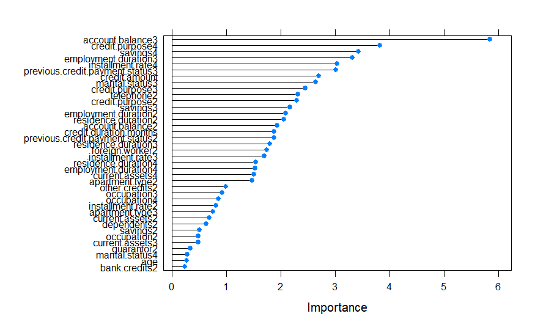

```r
plot( importance )
```

## Model construct with 4 selected variables above

```r
formula.2 <- 'credit.rating  ~ account.balance + credit.purpose + savings + employment.duration'
formula.2 <- as.formula( formula.new )

model_rl_2 <- glm( formula = formula.2, data = train.data, family = 'binomial' )
```

## Summary of model 2

```r
summary( model_rl_2 )
```

```
Call:
glm(formula = formula.2, family = "binomial", data = train.data)

Deviance Residuals:
    Min       1Q   Median       3Q      Max
-2.2743  -0.9948   0.5130   0.8154   1.5843

Coefficients:
                     Estimate Std. Error z value Pr(>|z|)
(Intercept)           0.05252    0.38305   0.137  0.89095
account.balance2      0.46761    0.22278   2.099  0.03582 *
account.balance3      1.68063    0.22961   7.320 2.49e-13 ***
credit.purpose2      -0.49840    0.38371  -1.299  0.19398
credit.purpose3      -0.51539    0.36225  -1.423  0.15481
credit.purpose4      -0.97201    0.35859  -2.711  0.00672 **
savings2             -0.02764    0.29991  -0.092  0.92657
savings3              0.77600    0.35121   2.209  0.02714 *
savings4              0.70529    0.26473   2.664  0.00772 **
employment.duration2  0.49713    0.23975   2.074  0.03812 *
employment.duration3  0.92586    0.28581   3.239  0.00120 **
employment.duration4  0.49513    0.25602   1.934  0.05312 .
---
Signif. codes:  0 ‘***’ 0.001 ‘**’ 0.01 ‘*’ 0.05 ‘.’ 0.1 ‘ ’ 1

(Dispersion parameter for binomial family taken to be 1)

    Null deviance: 853.51  on 699  degrees of freedom
Residual deviance: 733.82  on 688  degrees of freedom
AIC: 757.82

Number of Fisher Scoring iterations: 4
```